# ISoP Student Metrics Munch (M&M) Newsletter

## **ISoP Student Metrics Munch (M&M) Newsletter**

2020-10-01

Hello, Aspirant Pharmacometricians!

The ISoP Student Group will be publishing M&M Newsletter *quarterly* in September, December, March, and June. Please also to check out our [website](https://isop-student-community.github.io/isop-student-community/vol.html) for more information about our community and join ISoP Student Community by filling out the [Steering Committee Volunteer Form](https://docs.google.com/forms/d/1fATom6Ts1jiMBAhJ_Sed_9q_J_L8_yssJ5DjIWg7cHg/edit)

# Contents

> **Recent Graduate**

> **Meme it Up!!**

> **Pharmacokinetic models in clinical care**

> **Looking for Jobs/Internships?**

> **Join the ISoP/ISoP Student Community**

### **Recent Graduate**

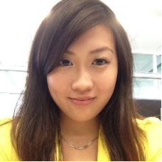

**Congratulations to *Yi Ting (Kayla) Lien, Ph.D.***, the past Chair of ISoP Student Community, who recently graduated from the Center for Pharmacometrics & System Pharmacology, College of Pharmacy at the University of Florida.

[Check out](https://docs.google.com/document/d/e/2PACX-1vQIawW9hlUITSSeRV_JJopTkVlbF4OBVtDQC_XnesML5ndxUcf0cI6iGjem57IkGVKfJwvg2gU13EeB/pub) the interview with Kayla on her experiences in ISoP, pharmacometrics, and her tips for current graduate students!

### **Meme it Up!!**

[figure not shown]

**Meme it up**! Community Challenge. Get creative and come up with memes for provided templates. Best ones get featured on our website!

[Challenge Accepted!](https://docs.google.com/forms/d/e/1FAIpQLScdtIjG_aX732P5lu9I_LNXOd5auRfXjdIdTx3vm_BC7_brYA/viewform)

### **Pharmacokinetic models in clinical care**

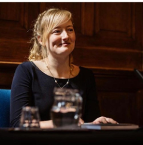

**Pharmacokinetic Models in Clinical Care by *Anette Veringa, Pharm.D.***

### **Looking for Jobs/Internships?**

Jobs and internships in Pharmacometrics/ Clinical Pharmacology around the globe

[View the lists](https://docs.google.com/document/d/e/2PACX-1vS29u5RMoAFYTT9YT82BftThLcEpmNuBdtatdFz8gLrq2EfjEKtR_ovnU-TmsZs5HSBFq6Hqn3tSD4y/pub)

### **Join the ISoP/ISoP Student Community**

[Join as an ISoP Member](http://go-isop.org/benefits/)

[Join the ISoP Student Community](https://isop-student-community.github.io/isop-student-community/vol.html)

**Thank you!**

*ISoP Student Communication team*

- If you want to be added to the ISoP Communications email list, please contact Zaid Temrikar: ztemrika@uthsc.edu
- If you have ideas for events, please email Zaid Temrikar: ztemrika@uthsc.edu or Anne-Grete Märtson: a.martson@umcg.nl